# Forking paths - second study

# 1 Introduction

This notebook generates the results of the second study in the paper **Forking paths in empirical studies** available on [SSRN](https://papers.ssrn.com/sol3/papers.cfm?abstract_id=3999379).  
The dataset for this part comes from Dacheng Xiu’s website (https://dachxiu.chicagobooth.edu/) and was slightly altered. It is a bit heavy and can be downloaded [here](https://drive.google.com/file/d/1Ojil9k7DaSrVSo7H5G_WdDpQoz6JjlrG/view?usp=sharing).

**WARNING**: he code for this part takes much longer, roughly 11 hours on a 2018 MacBook Pro.  
The **code** is also folded to ease readability. Click on the corresponding buttons to access it.

# 2 Setup

First, we load packages & import the data.  
And take a brief look.

```r
options(future.globals.maxSize= 891289600*10)
rstudioapi::writeRStudioPreference("data_viewer_max_columns", 200L)   # Allows to view up to 200 columns
```

```r
library(tidyverse)                                                    # Data wrangling package
library(readxl)                                                       # Read excel files
library(data.table)                                                   # Fast wrangling!
library(purrr)                                                        # Functional programming
library(fst)                                                          # Fast reading & writing of dataframes
library(dtplyr)                                                       # Combining dplyr & data.table
library(lubridate)                                                    # Date management
library(ggallin)                                                      # Addin to ggplot for negative log scales
library(viridis)                                                      # Cool color palette
library(patchwork)                                                    # To layout graphs
library(latex2exp)                                                    # LaTeX in graphs
library(tictoc)                                                       # CPU timing
library(furrr)                                                        # Parallel computing

data_paths <- read_fst("data/data_paths.fst")                         # Loading main dataset
specs <- read_excel("data/ML_supp.xlsx")                              # Loading additional info
data_paths[,1:9] |> head(10) |> knitr::kable()                       # A snapshot
```

| permno | Date | mvel1 | beta | betasq | chmom | dolvol | idiovol | indmom |
| --- | --- | --- | --- | --- | --- | --- | --- | --- |
| 10000 | 1986-02-28 | 16100.000 | NA | NA | NA | NA | NA | 0.2111586 |
| 10000 | 1986-03-31 | 11960.000 | NA | NA | NA | NA | NA | 0.2624714 |
| 10000 | 1986-04-30 | 16330.000 | NA | NA | NA | 7.897668 | NA | 0.3269873 |
| 10000 | 1986-05-30 | 15172.000 | NA | NA | NA | 8.472954 | NA | 0.3479495 |
| 10000 | 1986-06-30 | 11793.859 | NA | NA | NA | 8.250098 | NA | 0.3572053 |
| 10000 | 1986-07-31 | 11734.594 | NA | NA | NA | 8.113567 | NA | 0.4227055 |
| 10000 | 1986-08-29 | 10786.344 | NA | NA | NA | 8.103863 | NA | 0.3973749 |
| 10000 | 1986-09-30 | 4148.594 | NA | NA | NA | 8.103882 | NA | 0.3032582 |
| 10000 | 1986-10-31 | 3911.531 | NA | NA | NA | 8.112181 | NA | 0.3860786 |
| 10000 | 1986-11-28 | 3002.344 | NA | NA | NA | 8.205756 | NA | 0.2561681 |

The original dataset has strong variations in the number of well-defined fields before 1983.  
Thus, we truncate the sample before this date.  
Before that, we also remove a few predictors not suited for the sorting study (e.g., binary-valued).

```r
data_paths <- data_paths |> filter(Date > "1983-01-01") # Stability filter
data_paths <- data_paths |> arrange(Date, permno)       # Order
dates <- data_paths$Date |> unique() |> sort()          # Vector of dates
features <- specs |> pull(Acronym)                        # Predictors / firm characteristics
features <- setdiff(features, c("age", "convind", "divi", "divo", "ms", "nincr", "ps", "rd", "rd_sale", "realestate", "securedind", "sin"))
data_paths <- data_paths |>
    select(all_of(c("permno", "Date", "Return", features)))
```

# 3 The modules

Empirical work in the paper is modelled as chains of modules.

```r
module_variable <- function(data, variable){
    #save(variable, file = paste0(Sys.time(), "_variable.RData"))
    if(!(variable %in% c("mvel1", "retvol"))){
        return(data |>
                   dplyr::select(all_of(c("permno", "Date", "Return", "mvel1", "retvol", variable))) |>
                   purrr::set_names(c("permno", "Date", "Return", "mvel1", "retvol", "variable")))
    }
    if(variable == "mvel1"){
        return(data |>
                   dplyr::select(all_of(c("permno", "Date", "Return", "mvel1", "retvol"))) |>
                   mutate(variable = mvel1))
    }
    if(variable == "retvol"){
        return(data |>
                   dplyr::select(all_of(c("permno", "Date", "Return", "mvel1", "retvol"))) |>
                   mutate(variable = retvol))
    }
}

impute <- function(v){
    v[is.na(v)] <- median(v, na.rm = T)
    return(v)
}

module_imputation <- function(data, imputation){
    if(imputation == 0){return(data)}
    if(imputation == 1){
        return(
            data |>
                group_by(Date) |>
                mutate(variable = impute(variable)) |>
                ungroup()
        )
    }
}

module_horizon <- function(data, horizon){
    vol_thresh <- 0.001 # hard-coded!
    if(horizon == 1){return(data |> na.omit() |> filter(retvol > vol_thresh))}
    if(horizon == 2){
        return(data |>
                   group_by(permno) |>
                   mutate(Return = (Return + dplyr::lead(Return)) / horizon) |> # Returns are scaled to the monthly scale
                   ungroup() |>
                   na.omit() |>
                   filter(retvol > vol_thresh)
        )
    }
    if(horizon == 3){
        return(data |>
                   group_by(permno) |>
                   mutate(Return = (Return + dplyr::lead(Return) + dplyr::lead(Return, 2)) / horizon) |>
                   ungroup() |>
                   na.omit() |>
                   filter(retvol > vol_thresh)
        )
    }
}

module_start <- function(data, start_quantile){
    L <- nrow(data)
    data[ceiling(L*start_quantile):L, ]
}

module_stop <- function(data, stop_quantile){
    L <- nrow(data)
    data[1:ceiling(L*stop_quantile), ]
}

module_thresh_type <- function(data, thresh_type){
    type <- substr(thresh_type,(nchar(thresh_type)-1),nchar(thresh_type))
    thresh <- substr(thresh_type, 1, (nchar(thresh_type)-3)) |> as.numeric()
    if(type == "EW"){
        return(list(t = data |>
                        group_by(Date) |>
                        mutate(type = case_when(
                            variable <= quantile(variable, thresh, na.rm = T) ~ "Short",
                            variable >= quantile(variable, 1 - thresh, na.rm = T) ~ "Long")
                        ) |>
                        # mutate(type = if_else(variable < quantile(variable, thresh, na.rm = T), "Short",
                        #                       if_else(variable > quantile(variable, 1 - thresh, na.rm = T), "Long", "Neutral"))) |>
                        pivot_wider(names_from = "type", values_from = "Return") |>
                        group_by(Date) |>
                        summarize(ret = mean(Long, na.rm = T) - mean(Short, na.rm = T)) |>
                        summarise(m = mean(ret, na.rm = T),
                                  s = sd(ret, na.rm = T),
                                  n = length(ret)) |> as.numeric()))    # Returns monthly avg returns & vol
    }
    if(type == "VW"){
        return(list(t = data |>
                        group_by(Date) |>
                        mutate(type = case_when(
                            variable <= quantile(variable, thresh, na.rm = T) ~ "Short",
                            variable >= quantile(variable, 1 - thresh, na.rm = T) ~ "Long")
                        ) |>
                        # mutate(type = if_else(variable < quantile(variable, thresh, na.rm = T), "Short",
                        #                       if_else(variable > quantile(variable, 1 - thresh, na.rm = T), "Long", "Neutral"))) |>
                        pivot_wider(names_from = "type", values_from = "Return") |>
                        mutate(is_Long = is.finite(Long),
                               is_Short = is.finite(Short)) |>
                        group_by(Date) |>
                        summarize(ret = sum(Long*mvel1, na.rm = T)/sum(is_Long*mvel1, na.rm = T) -
                                      sum(Short*mvel1, na.rm = T)/sum(is_Short*mvel1, na.rm = T)) |>
                        summarise(m = mean(ret, na.rm = T),
                                  s = sd(ret, na.rm = T),
                                  n = length(ret)) |> as.numeric()))    # Returns monthly avg returns & vol
    }
    if(type == "IW"){
        return(list(t = data |>
                        group_by(Date) |>
                        mutate(type = case_when(
                            variable <= quantile(variable, thresh, na.rm = T) ~ "Short",
                            variable >= quantile(variable, 1 - thresh, na.rm = T) ~ "Long")
                        ) |>
                        # mutate(type = if_else(variable < quantile(variable, thresh, na.rm = T), "Short",
                        #                       if_else(variable > quantile(variable, 1 - thresh, na.rm = T), "Long", "Neutral"))) |>
                        pivot_wider(names_from = "type", values_from = "Return") |>
                        mutate(is_Long = is.finite(Long),
                               is_Short = is.finite(Short)) |>
                        group_by(Date) |>
                        summarize(ret = sum(Long/retvol, na.rm = T)/sum(is_Long/retvol, na.rm = T) -
                                      sum(Short/retvol, na.rm = T)/sum(is_Short/retvol, na.rm = T)) |>
                        summarise(m = mean(ret, na.rm = T),
                                  s = sd(ret, na.rm = T),
                                  n = length(ret)) |> as.numeric()))    # Returns monthly avg returns & vol
    }
    if(type == "CW"){
        return(list(t = data |>
                        group_by(Date) |>
                        mutate(type = case_when(
                            variable <= quantile(variable, thresh, na.rm = T) ~ -1,
                            variable >= quantile(variable, 1 - thresh, na.rm = T) ~ 1)
                        ) |>
                        # mutate(type = if_else(variable < quantile(variable, thresh, na.rm = T), "Short",
                        #                       if_else(variable > quantile(variable, 1 - thresh, na.rm = T), "Long", "Neutral"))) |>
                        group_by(Date, type) |>
                        mutate(weight = variable / sum(variable, na.rm = T) * type ) |>
                        ungroup() |>
                        group_by(Date) |>
                        summarize(ret = sum(Return * weight, na.rm = T)) |>
                        summarise(m = mean(ret, na.rm = T),
                                  s = sd(ret, na.rm = T),
                                  n = length(ret)) |> as.numeric()))    # Returns monthly avg returns & vol
    }
}
```

A test below. There are 3 outputs: the **mean return**, the **vol** (standard deviation of returns) and the **sample size**.

```r
# A first test.
data_paths |>
    module_variable("pchcurrat") |>
    module_imputation(1) |>
    module_horizon(1) |>
    module_start(2/3) |>
    module_stop(1) |>
    module_thresh_type("0.5_CW")
```

```
## $t
## [1] -6.775826e-04  9.514384e-03  1.780000e+02
```

The aggregation (and a test).

```r
module_aggregator <- function(variable = variable,
                              imputation = imputation,
                              horizon = horizon,
                              start_quantile = start_quantile,
                              stop_quantile = stop_quantile,
                              thresh_type = thresh_type){
    data_paths |>
        module_variable(variable = variable) |>
        module_imputation(imputation = imputation) |>
        module_horizon(horizon = horizon) |>
        module_start(start_quantile = start_quantile) |>
        module_stop(stop_quantile = stop_quantile) |>
        module_thresh_type(thresh_type = thresh_type)
}

# Test!
module_aggregator(variable = "absacc",
                  imputation = 0,
                  horizon = 1,
                  start_quantile = 0,
                  stop_quantile = 1/3,
                  thresh_type = "0.1_EW")
```

```
## $t
## [1]  -0.006979506   0.026148222 168.000000000
```

Surprisingly, we discovered that slicing the parallelization improves its speed, hence the slightly heavy loop below.  
Running the future_map() function over 44K parameters was too slow (and penalizing upon errors).

# 4 The main run

Below, we specify the layer options and launch the spanning of all paths. For each anomaly, one output file is created with the “*_results_fork.RData*” suffix.  
The results for the CW weighting scheme (characteristics-weighted) are run separately with

thresh <- 0.5 type <- “CW”

```r
imputation <- c(0,1)
horizon <- 1:3
start_quantile <- c(0, 1/3, 2/3)
stop_quantile <- c(1/3, 2/3, 1)
thresh <- c(0.1, 0.15, 0.2, 0.25, 0.3)
type <- c("EW", "VW", "IW")
for(i in 1:length(features)){ # PB 63
    if(i%%5==0){print(i)}
    variable <- features[i]
    pars <- expand_grid(variable, imputation, horizon, start_quantile, stop_quantile, thresh, type) |>
        filter(stop_quantile > start_quantile)
    pars2 <- pars |> mutate(thresh_type = paste0(thresh, "_", type)) |>
        select(-thresh, -type)
    plan(multisession, workers = 4)                                # Set the number of cores
    if(i%%10==0){tictoc::tic()}                                    # Launch timer
    output <- future_pmap_dfr(pars2,  module_aggregator)           # Parallel routine
    if(i%%10==0){tictoc::toc()}                                    # Stop timer
    results <- cbind(pars, matrix(output$t, ncol = 3, byrow = T))  # Bind parameters to results
    colnames(results)[8:10] <- c("avg_return", "vol", "n")
    save(results, file = paste0(variable, "_results_fork.RData"))
}
```

```r
results_full <- c()
filenames <- list.files("output_4", pattern="*.RData", full.names = TRUE)
for(j in 1:length(filenames)){
    load(filenames[j])
    results_full <- bind_rows(results_full, results)
}
#save(results_full, file = "results_full.RData")
```

# 5 Plots

Below, we show the boxplots of t-statistics for each firm characteristic.  
The two numbers below are the average hacking intervals for robustness checks versus all paths.

```r
res_baseline <- results_full |>
    bind_rows(results_full_cw) |>          # Adding CW cases
    mutate(t = sqrt(n)*avg_return/vol) |>
    group_by(variable) |>
    mutate(m = median(t),
           t = if_else(m>0, t, -t),
           m = median(t)) |>
    filter(imputation == 1,
           horizon == 1,
           start_quantile == 0,
           stop_quantile == 1,
           thresh == 0.2,
           type == "EW")

res_robust <- results_full |>
    bind_rows(results_full_cw) |>
    mutate(t = sqrt(n)*avg_return/vol,) |>
    group_by(variable) |>
    mutate(m = median(t),
           t = if_else(m>0, t, -t),
           m = median(t)) |>
    #(imputation == 1, horizon == 1, start_quantile == 0, stop_quantile == 1, thresh == 0.2, type == "EW") |
    filter( (horizon == 1 & start_quantile == 0 & stop_quantile == 1 & thresh == 0.2 & type == "EW") |
                (imputation == 1 & start_quantile == 0 & stop_quantile == 1 & thresh == 0.2 & type == "EW") |
                (imputation == 1 & horizon == 1 & stop_quantile == 1 & thresh == 0.2 & type == "EW") |
                (imputation == 1 & horizon == 1 & start_quantile == 0 & thresh == 0.2 & type == "EW") |
                (imputation == 1 & horizon == 1 & start_quantile == 0 & stop_quantile == 1 & type == "EW") |
                (imputation == 1 & horizon == 1 & start_quantile == 0 & stop_quantile == 1 & thresh == 0.2)
    ) |>
    group_by(variable) |>
    mutate(min = min(t),
           max = max(t),
           hackint = max - min) |>
    ungroup()

res_robust |> summarise(mean(hackint))
```

```
## # A tibble: 1 × 1
##   `mean(hackint)`
##             <dbl>
## 1            4.10
```

```r
results_full |>
    bind_rows(results_full_cw) |>
    mutate(t = sqrt(n)*avg_return/vol) |>
    group_by(variable) |>
    mutate(min = min(t),
           max = max(t),
           hackint = max - min) |>
    ungroup() |>
    summarise(mean(hackint))
```

```
## # A tibble: 1 × 1
##   `mean(hackint)`
##             <dbl>
## 1            9.06
```

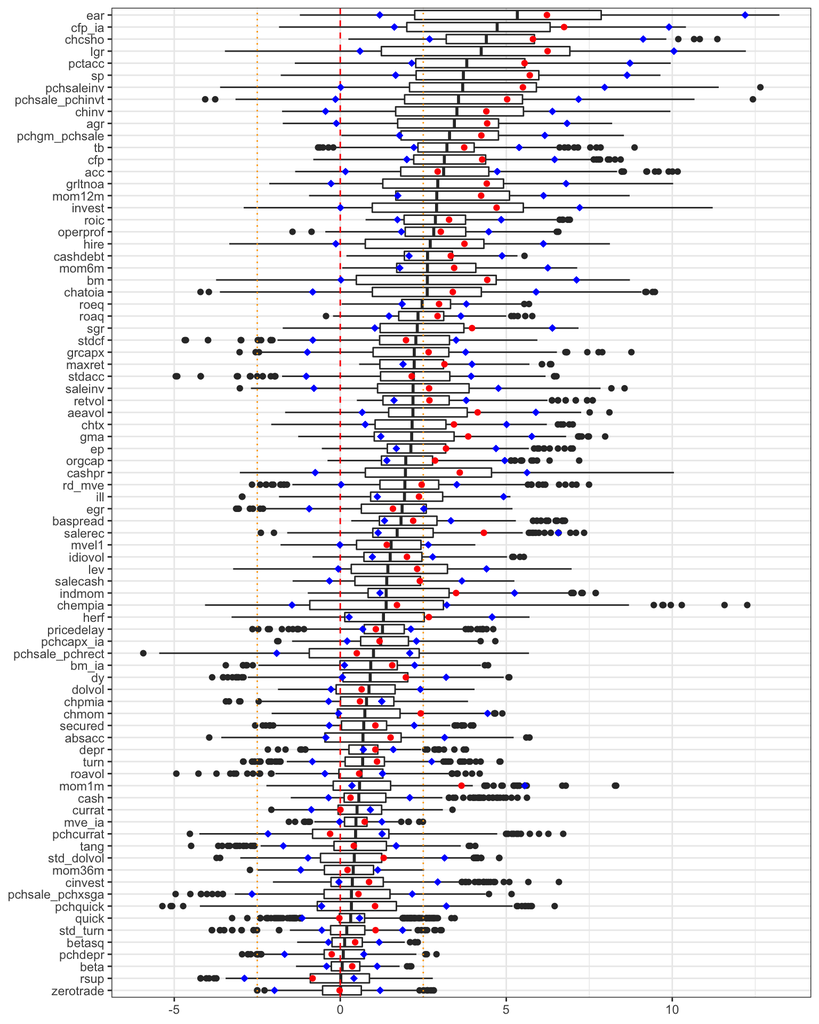

```r
results_full |>
    bind_rows(results_full_cw) |>
    mutate(t = sqrt(n)*avg_return/vol) |>
    group_by(variable) |>
    mutate(m = median(t),
           t = if_else(m>0, t, -t),
           m = median(t)) |>
    ggplot(aes(y = reorder(variable, m), x = t)) +
    geom_boxplot() + theme_bw() +
    geom_vline(xintercept = 0, linetype = 2, color = "red") +
    geom_vline(xintercept = -2.5, linetype = 3, color = "orange") +
    geom_vline(xintercept = 2.5, linetype = 3, color = "orange") +
    theme(axis.title = element_blank()) +
    geom_point(data = res_baseline, color = "red") +
    geom_point(data = res_robust, aes(x = min), color = "blue", shape = 18, size = 2) +
    geom_point(data = res_robust, aes(x = max), color = "blue", shape = 18, size = 2)
```

```r
#ggsave("t_stats_anom.pdf", width = 8.4, height = 10)
```

# 6 Generating boostraped series

First, we need baseline results for the anomalies.  
We consider 2 month holding periods, over the whole sample, with a breakpoint at 0.2 (i.e. 0.8 for the upper tail).

```r
module_fixed <- function(data){ # This is the final module with fixed values, weighting is EW
    thresh <- 0.2
    data |>
        group_by(Date) |>
        mutate(type = case_when(
            variable <= quantile(variable, thresh, na.rm = T) ~ "Short",
            variable >= quantile(variable, 1 - thresh, na.rm = T) ~ "Long")
        ) |>
        # mutate(type = if_else(variable < quantile(variable, thresh, na.rm = T), "Short",
        #                       if_else(variable > quantile(variable, 1 - thresh, na.rm = T), "Long", "Neutral"))) |>
        pivot_wider(names_from = "type", values_from = "Return") |>
        group_by(Date) |>
        summarize(ret = mean(Long, na.rm = T) - mean(Short, na.rm = T))   # Returns monthly  returns
}


mod_horz <- 2
m_testing <- matrix(0, ncol = length(features), nrow = length(dates)-mod_horz)
for(v in 1:length(features)){
    if(v %% 20 == 0 ){print(v)}
    m_testing[,v] <- data_paths |>
        module_variable(features[v]) |>
        module_imputation(1) |>
        module_horizon(mod_horz) |>
        module_start(0) |>
        module_stop(1) |>
        module_fixed() |>
        pull(ret)
}
save(m_testing, file = "m_testing.RData")
```

```r
block_boot <- function(X, block_size = 12){            # This function is for simple bootstrap
    TT <- nrow(X)
    l <- floor(TT/block_size)
    ind <- sample(1:(TT-block_size+1), l, replace = F) # No index twice
    Z <- c()
    for(j in 1:l){
        Z <- rbind(Z, X[ind[j]:(ind[j]+block_size-1),])
    }
    remainz <- TT - floor(TT/block_size) * block_size
    Z <- rbind(Z, X[sample(1:TT, remainz),])
    return(Z)
}

brc <- function(X, block_size = 12, B = 10){           # This codes the BRC
    Z <- array(0, dim = c(B, nrow(X), ncol(X)))
    mu <- apply(X, 2, mean)
    mu <- matrix(mu, nrow = B, ncol = ncol(X), byrow = T)
    for(b in 1:B){
        Z[b,,] <- block_boot(X, block_size)
    }
    mu_B <- apply(Z, c(1,3), mean) - mu
    s_B <- apply(Z, c(1,3), sd)
    mu_B/s_B*sqrt(nrow(X))
}

# Below we make sure anomalies are in the correct direction
for(j in 1:ncol(m_testing)){
    if(sum(m_testing[,j]) < 0){m_testing[,j] = -m_testing[,j]}
}


t_testing <- brc(m_testing, 12, 576) |> t()
t_testing <- apply(t_testing, 2, sort)
```

# 7 Exhaustive Multiple Testing

We can then combine paths-generated outputs and multiple testing and compare to bootstrapped series.

```r
m <- results_full |>
    #bind_rows(results_full_cw) |>
    mutate(m = avg_return) |>
    filter(imputation == 1,
           horizon == 1,
           start_quantile == 0,
           stop_quantile == 1,
           thresh == 0.2,
           type == "EW") |>
    select(all_of(c("variable", "m")))

m_max <- results_full |>
    #bind_rows(results_full_cw) |>
    filter(imputation == 1,
           horizon == 1,
           start_quantile == 0,
           stop_quantile == 1,
           thresh == 0.2,
           type == "EW") |>
    mutate(t = abs(sqrt(n) * avg_return/vol)) |>
    pull(t) |>
    max()
t_exhaust_1 <- results_full |>
    bind_rows(results_full_cw) |>
    left_join(m, by = "variable") |>
    mutate(t = sqrt(n)*(avg_return-m)/vol,
           id = row_number()) |>
    group_by(variable) |>
    mutate(m_t = mean(t),
           t = t*sign(m_t)) |> # Correct direction
    ungroup() |>
    select(all_of(c("variable", "t"))) |>
    pivot_wider(names_from = variable, values_from = t) |>
    tidyr::unnest() |>
    as.matrix() |>
    t()
t_exhaust_2 <- results_full |>
    bind_rows(results_full_cw) |>
    mutate(id = row_number()) |>
    group_by(variable) |>
    mutate(m = mean(avg_return)) |>
    ungroup() |>
    mutate(t = sqrt(n)*(avg_return-mean(avg_return))/vol) |>
    group_by(variable) |>
    mutate(m_t = mean(t),
           t = t*sign(m_t)) |> # Correct direction
    ungroup() |>
    select(all_of(c("variable", "t"))) |>
    pivot_wider(names_from = variable, values_from = t) |>
    tidyr::unnest() |>
    as.matrix() |>
    t()
t_exhaust_1 <- apply(t_exhaust_1, 2, sort)
t_exhaust_2 <- apply(t_exhaust_2, 2, sort)
```

Now let’s have a look at the distribution of maximum statistics.

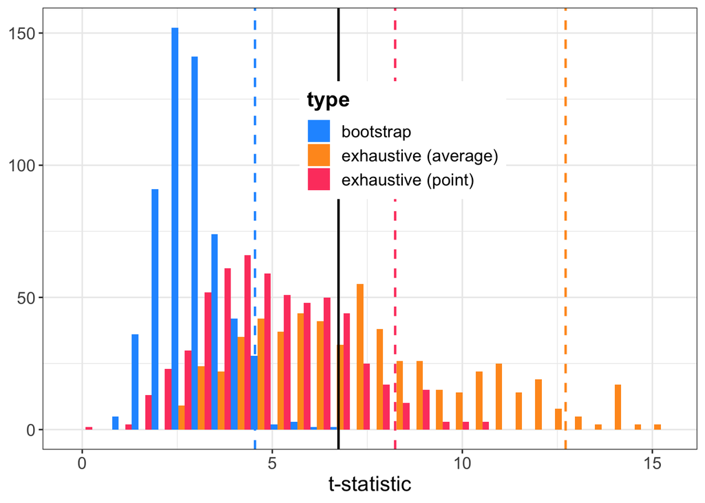

```r
#t_brc <- ((sqrt(nrow(m_testing))*(m_testing |> colMeans()) / (apply(m_testing, 2, sd))) |> abs()) |> max()
t_brc <- res_baseline |> arrange(desc(t)) |> head(1) |> pull(t)

bind_rows(
    data.frame(type = "bootstrap", t = t_testing[nrow(t_testing),]),
    data.frame(type = "exhaustive (point)", t = t_exhaust_1[nrow(t_exhaust_1),]),
    data.frame(type = "exhaustive (average)", t = t_exhaust_2[nrow(t_exhaust_2),])
) |>
    ggplot(aes(x = t, fill = type)) + geom_histogram(position = "dodge") +
    theme_bw() +
    theme(legend.position = c(0.55,0.7),
          text = element_text(size = 15),
          legend.title = element_text(face = "bold"),
          axis.title.y = element_blank()) + xlab("t-statistic") +
    geom_vline(xintercept = quantile(t_testing[nrow(t_testing),], 0.95), linetype = 2, color = "#2299FF", size = 0.8) +
    geom_vline(xintercept = t_brc, linetype = 1, color = "#000000", size = 0.8) +
    geom_vline(xintercept = quantile(t_exhaust_1[nrow(t_exhaust_1),], 0.95), linetype = 2, color = "#FE476E", size = 0.8) +
    geom_vline(xintercept = quantile(t_exhaust_2[nrow(t_exhaust_2),], 0.95), linetype = 2, color = "#FF9922", size = 0.8) +
    scale_fill_manual(values = c("#2299FF", "#FF9922", "#FE476E"))
```

```r
ggsave("EMT.pdf", width = 8, height = 4)
```

# 8 Impact of weighting scheme

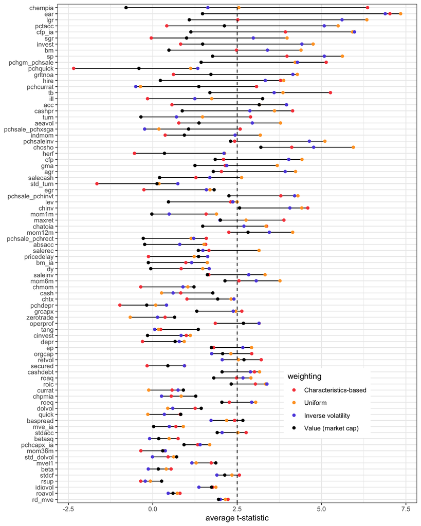

```r
results_full |>
    bind_rows(results_full_cw) |>
    mutate(t = sqrt(n)*avg_return/vol) |>
    group_by(variable) |>
    mutate(m = median(t),
           t = if_else(m>0, t, -t),
           m = median(t)) |>
    group_by(variable, type) |>
    summarise(t = mean(t)) |>
    mutate(diff = max(t) - min(t)) |>
    ggplot(aes(x = t, y = reorder(variable, diff), color = type)) +
    geom_line(color = "black") + theme_bw() +
    geom_point() +
    theme(axis.title.y = element_blank(),
          legend.position = c(0.75, 0.2)) +
    geom_vline(xintercept = 2.5, linetype = 2) +
    scale_color_manual(name = "weighting", values = c("#F74646", "#FFA22B", "#5E51E0", "#000000"),
                       labels = c("Characteristics-based", "Uniform", "Inverse volatility", "Value (market cap)")) +
    xlab("average t-statistic")
```

```r
#ggsave("t_weighting.pdf", width = 8.4, height = 10)
```

Let’s see how that translates in terms of cdf.

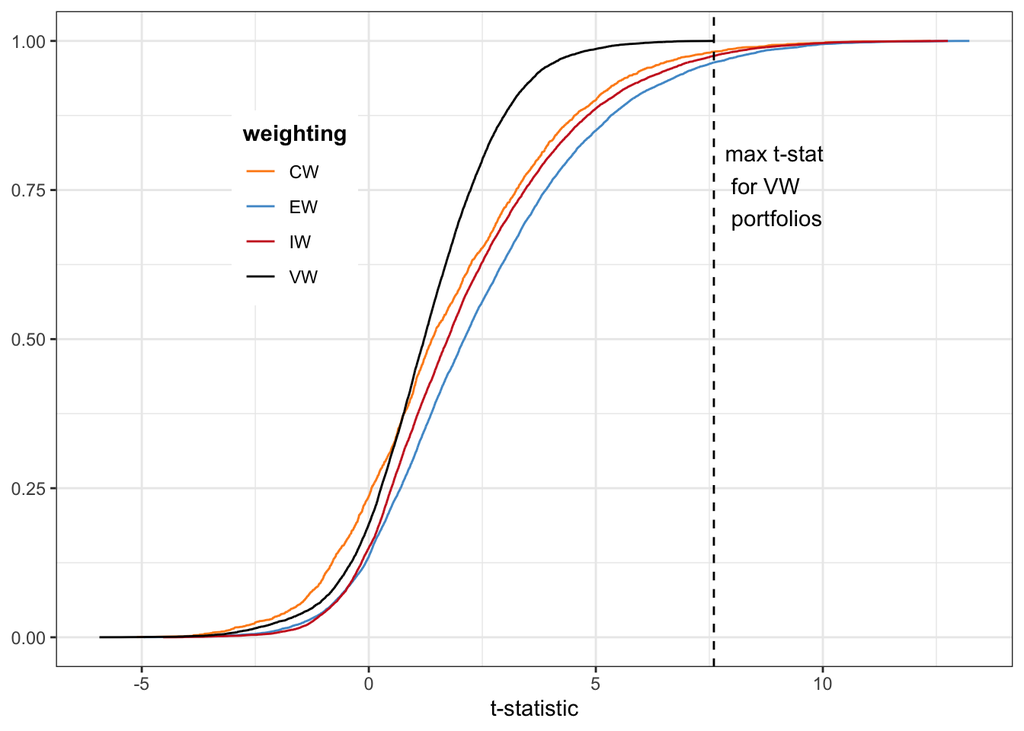

```r
results_full |>
    bind_rows(results_full_cw) |>
    mutate(t = sqrt(n)*avg_return/vol) |>
    group_by(variable) |>
    mutate(m = median(t),
           t = if_else(m>0, t, -t)  ) |>
    ungroup() |>
    group_by(type) |>
    mutate(v = ecdf(t)(t)) |>
    ggplot(aes(x = t, y = v, color = type)) + #geom_histogram(position = "dodge") +
    geom_line() + theme_bw() +
    scale_color_manual(values = c("#FE8C1A", "#4F99D0", "#CC2222", "#000000"), name = "weighting") +
    theme(legend.position = c(0.25,0.7),
          legend.title = element_text(face = "bold"),
          axis.title.y = element_blank()) +
    xlab("t-statistic") +
    geom_vline(xintercept = 7.6, linetype = 2) +
    annotate("text", x = 9, y = 0.7, label = TeX("max t-stat \n for VW \n portfolios"))
```

```r
ggsave("t_cdf.pdf", width = 8, height = 4)
```

# 9 p-value distribution & vicious hacking

The next step is to extract the histogram values on the [0,1/2] interval. Because we work with bins with 0.1 width, this makes only 5 values.

```r
n_i <- function(v, bins){         # Function that extracts the values
    temp <- hist(v, breaks = bins, plot = F)
    temp$counts
}

n <- 10
bins <- (0:n)/n

table_counts <- results_full |>
    bind_rows(results_full_cw) |>
    mutate(t = sqrt(n)*avg_return/vol) |>
    group_by(variable) |>
    mutate(m = median(t),
           t = if_else(m>0, t, -t)  ) |>
    ungroup() |>
    mutate(t = 1-pnorm(t)) |>
    group_by(variable) |>
    summarise(counts = n_i(t, bins)) |>
    mutate(quantile = row_number()) |>
    pivot_wider(names_from = variable, values_from = counts) |>
    data.matrix()
crit_1 <- 4

table_counts <- table_counts + 1 # to avoid issues when counts are zero


crit <- (lead(table_counts) / table_counts ) / matrix(rep(1:nrow(table_counts), ncol(table_counts)),
           nrow = nrow(table_counts),
           ncol = ncol(table_counts),
           byrow = F)

criteria <- apply(crit[1:crit_1, -1], 2, mean, na.rm = T)  |>
            t() |>
            as_tibble(rownames = NA) |>
            pivot_longer(cols = everything(), names_to = "variable", values_to = "crit") |>
    mutate(criterion = if_else(crit < 0.25 , "unnecessary",
                               if_else(crit > 0.4, "problematic", "possible")),
           criterion = recode_factor(criterion,
                                     `unnecessary` = "unnecessary",
                                     `possible` = "possible",
                                     `problematic` = "problematic",
                                     .ordered = T
           ))

criteria |> group_by(criterion) |> count()
```

```
## # A tibble: 3 × 2
## # Groups:   criterion [3]
##   criterion       n
##   <ord>       <int>
## 1 unnecessary    37
## 2 possible       32
## 3 problematic    13
```

Let’s finally have a look at the distribution of *p*-values, sorting variable by sorting variable.

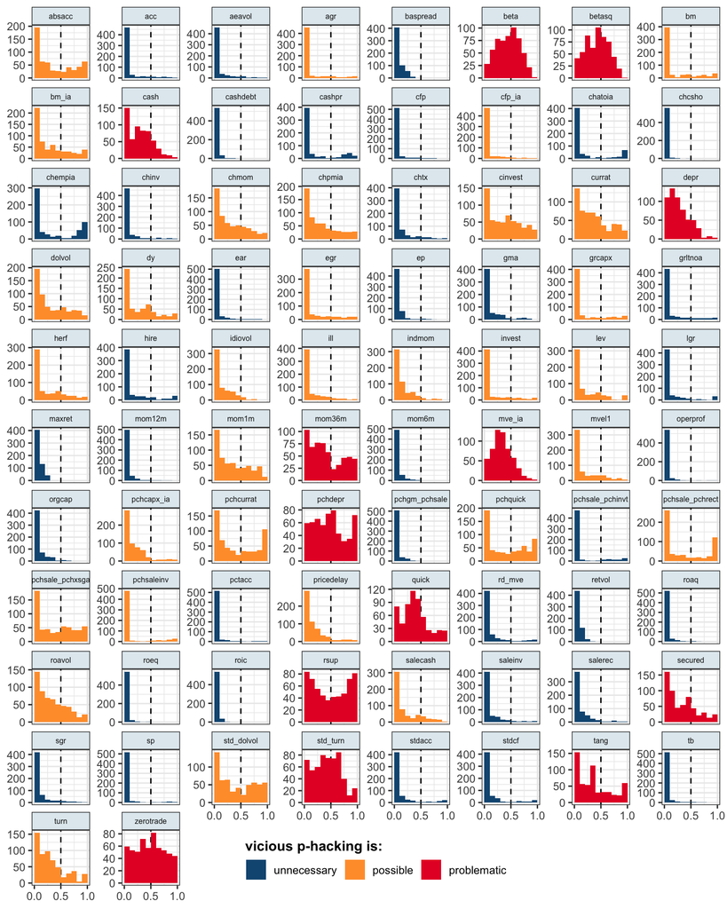

```r
results_full |>
    bind_rows(results_full_cw) |>
    mutate(t = sqrt(n)*avg_return/vol) |>
    group_by(variable) |>
    mutate(m = median(t),
           t = if_else(m>0, t, -t)  ) |>
    ungroup() |>
    mutate(t = 1-pnorm(t)) |>
    left_join(criteria, by = "variable") |>
    ggplot(aes(x = t, fill = criterion)) + geom_vline(xintercept = 0.5, linetype = 2) +
    geom_histogram(breaks = bins) +
    facet_wrap(vars(variable), ncol = 8, scales = "free_y") +
    theme_bw() +
    scale_x_continuous(breaks = c(0, 0.5, 1)) +
    scale_fill_manual(values = c("#115782", "#FF9D36", "#E7002E"), name = "vicious p-hacking is:") +
    theme(axis.title = element_blank(),
          legend.position = c(0.5, 0.03),
          legend.title = element_text(face = "bold"),
          strip.text = element_text(size = 6),
          strip.background = element_rect(fill = "#E1EBF0")) +
    guides(fill = guide_legend(nrow = 1, byrow = TRUE))
```

```r
ggsave("pval_dist.pdf", width = 8, height = 10)
```

```r
# old criteria
# table_harmonic <- #matrix(rep(1/(1:nrow(table_counts)), ncol(table_counts)),
#     matrix(rep(0.8^(0:(nrow(table_counts)-1)), ncol(table_counts)),
#            nrow = nrow(table_counts),
#            ncol = ncol(table_counts),
#            byrow = F) *
#     matrix(rep(table_counts[1,], nrow(table_counts)),
#            nrow = nrow(table_counts),
#            ncol = ncol(table_counts),
#            byrow = T) |> unlist() |> matrix(nrow = nrow(table_counts))
#
# c0 <- table_counts[1,-1] / apply(table_counts[,-1], 2, sum, na.rm = T)
# c1 <- table_counts[,-1] / lead(table_counts[,-1]) # Remove the 1st column and compare
# c2 <- (lead(table_counts[,-1]) / table_counts[, -1] )
# criteria <- c0 |>
#     t() |>
#     as_tibble(rownames = NA) |>
#     pivot_longer(cols = everything(), names_to = "variable", values_to = "crit0") |>
#     left_join(
#         apply(c1[1:(crit_1-1), ], 2, min, na.rm = T) |>
#             t() |>
#             as_tibble(rownames = NA) |>
#             pivot_longer(cols = everything(), names_to = "variable", values_to = "crit_order1_full"),
#         by = "variable") |>
#     left_join(
#         apply(c1[1:(crit_2-1), ], 2, min, na.rm = T) |>
#             t() |>
#             as_tibble(rownames = NA) |>
#             pivot_longer(cols = everything(), names_to = "variable", values_to = "crit_order1_mid"),
#         by = "variable") |>
#     left_join(
#         apply(c2[1:(crit_1-1), ] < 0.8, 2, sum, na.rm = T)  |>
#             t() |>
#             as_tibble(rownames = NA) |>
#             pivot_longer(cols = everything(), names_to = "variable", values_to = "crit_order2_full"),
#         by = "variable") |>
#     left_join(
#         apply(c2[1:(crit_2-1), ] < 0.8, 2, sum, na.rm = T)  |>
#             t() |>
#             as_tibble(rownames = NA) |>
#             pivot_longer(cols = everything(), names_to = "variable", values_to = "crit_order2_mid"),
#         by = "variable") |>
#     mutate(criterion = if_else((crit_order1_full >= 1) & (crit_order2_full == (crit_1-1)), "unnecessary",
#                                if_else(((crit_order1_mid >= 1) & (crit_order2_mid == (crit_2-1))) | crit0 > 0.7, "possible", "problematic")),
#            criterion = recode_factor(criterion,
#                                      `unnecessary` = "unnecessary",
#                                      `possible` = "possible",
#                                      `problematic` = "problematic",
#                                      .ordered = T
#            ))
```